*Draft! Prepared 2021-09-21 using country-reported data CSV files dated 2021-09-13 and estimates files dated 2021-08-16.*

### Table 3.1 Notifications of TB, HIV-positive TB, MDR/RR-TB and XDR-TB cases, globally and for WHO regions, 2020

| WHO region | Total notified | New and relapse<sup>a</sup> | Pulmonary new and relapse number | Pulmonary new and relapse bacteriologically confirmed (%) | Extrapulmonary new and relapse (%) | HIV-positive new and relapse | MDR/RR-TB only<sup>b</sup> | pre-XDR-TB or XDR-TB<sup>c</sup> |
| --- | --- | --- | --- | --- | --- | --- | --- | --- |
| African Region | 1 401 351 | 1 365 224 | 1 164 588 | 65% | 15% | 271 956 | 17 212 | 1 243 |
| Region of the Americas | 208 614 | 195 599 | 167 326 | 77% | 14% | 16 624 | 3 788 | 210 |
| South-East Asia Region | 2 767 444 | 2 560 817 | 1 954 385 | 56% | 24% | 53 380 | 55 298 | 9 672 |
| European Region | 195 701 | 159 803 | 132 637 | 67% | 17% | 19 466 | 25 979 | 12 026 |
| Eastern Mediterranean Region | 429 015 | 423 485 | 320 696 | 56% | 24% | 1 352 | 3 408 | 897 |
| Western Pacific Region | 1 141 563 | 1 119 817 | 1 020 204 | 55% | 9% | 13 185 | 26 537 | 1 633 |
| Global | 6 143 688 | 5 824 745 | 4 759 836 | 59% | 18% | 375 963 | 132 222 | 25 681 |

<sup>a</sup> *New and relapse* includes cases for which the treatment history is unknown. It excludes cases that have been re-registered as *treatment after failure*, as *treatment after lost to follow up* or as *other previously treated* (whose outcome after the most recent course of treatment is unknown or undocumented).  
<sup>b</sup> TB that is resistant to rifampicin, excluding any cases with known resistance to any fluroquinolone.  
<sup>c</sup> Pre-XDR-TB is TB that is resistant to rifampicin and to any fluoroquinolone. XDR-TB is TB that is resistant to rifampicin and to any fluoroquinolone and to at least one of bedaquiline or linezolid.

### Fig. 3.1.1 Notifications of TB cases (new and relapse cases, all forms) (black) compared with estimated TB incident cases (green), 2000–2020, globally and for WHO regions

Shaded areas represent uncertainty intervals

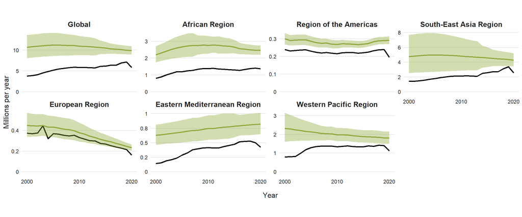

### Fig. 3.1.2 Notifications of TB cases (new and relapse cases, all forms) (black) compared with estimated TB incident cases (green), 2000–2020, 30 high TB burden countries

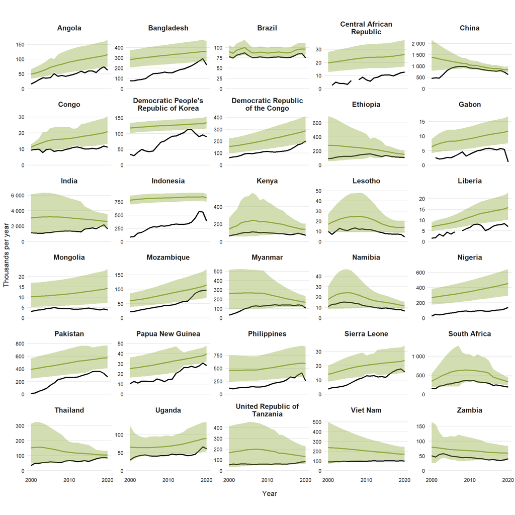

### Fig. 3.1.3 Global progress in the number of people treated for TB between 2018 and 2020, compared with cumulative targets set for 2018–2022 at the UN high-level meeting on TB

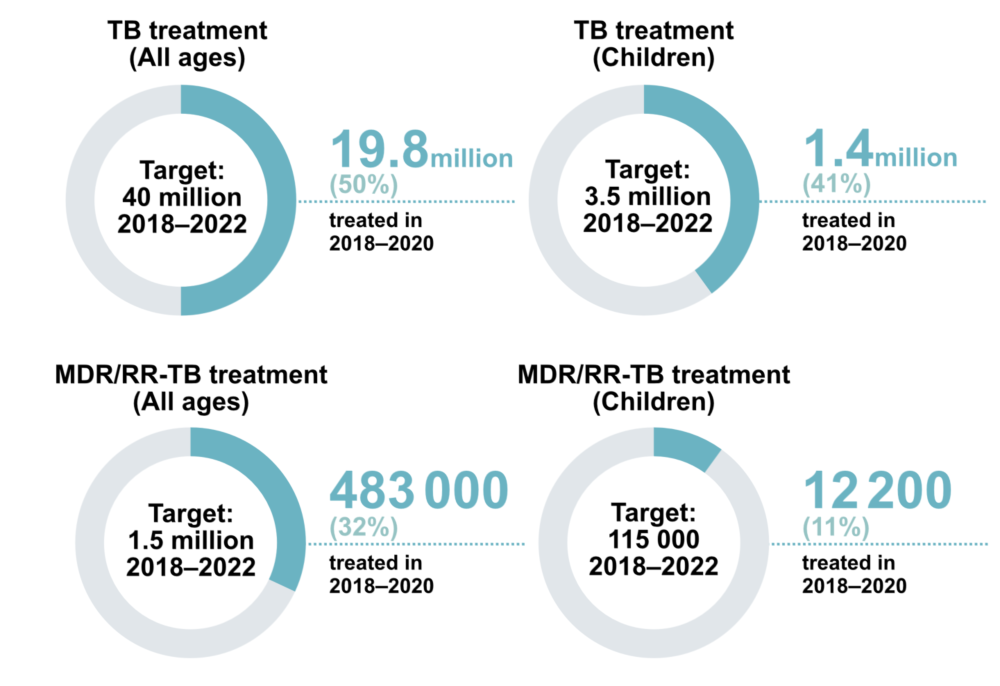

### Fig. 3.1.4 The global number of people reported to have been treated for TB disease, 2015–2020

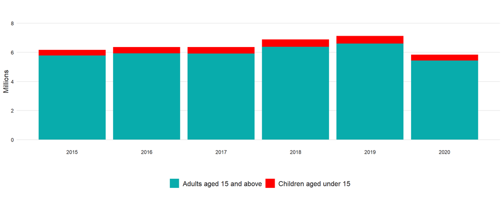

### Fig. 3.1.5 Estimated TB incidence (black outline) and new and relapse TB case notification rates by age group and sex<sup>a</sup> (female in purple; male in green) in 2020, globally and for WHO regions

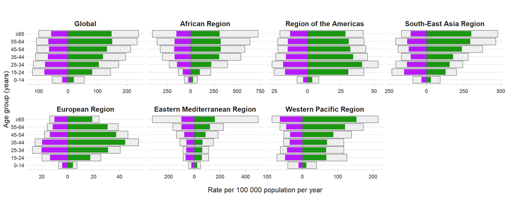

<sup>a</sup> Data from 26 countries and areas that did not report cases in these age categories are excluded. Cases included accounted for 98% of reported cases.

### Fig. 3.1.6 Percentage of new and relapse TB cases that were children (aged <15 years), 2020

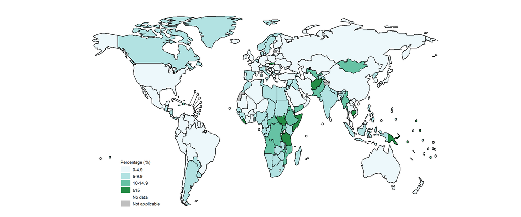

### Fig. 3.1.7 Percentage of extrapulmonary cases among new and relapse TB cases, 2020

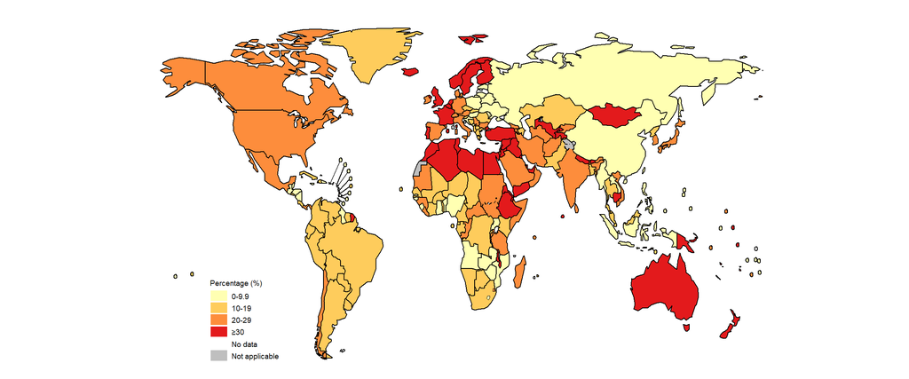

### Fig. 3.1.8 Contribution of public-private mix to TB case notifications in priority countries, 2010–2020

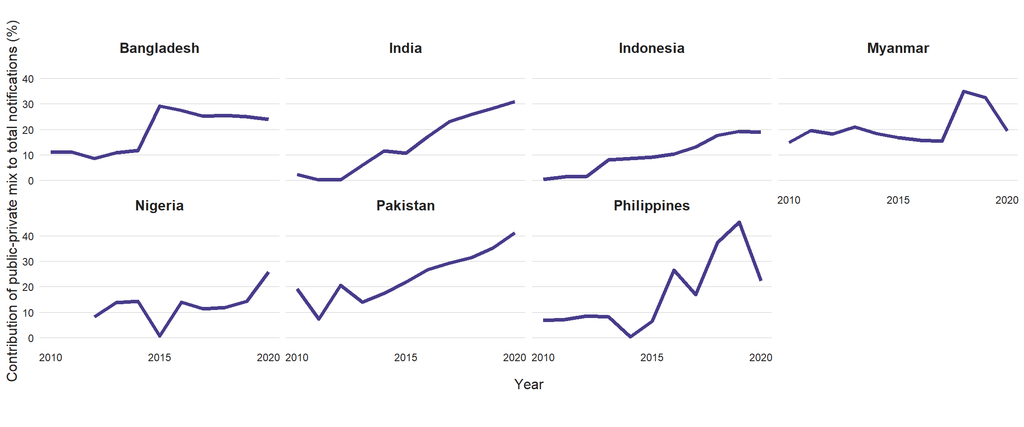

### Fig. 3.1.9 Percentage of basic management units in which there was community contribution to new case finding and/or to treatment adherence support,<sup>a</sup> 2020

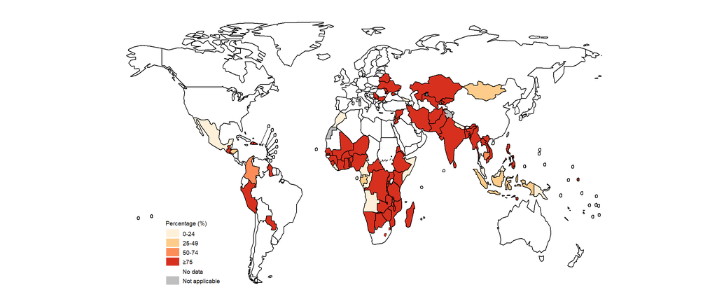

<sup>a</sup> Data only requested from 81 countries.

### Fig. 3.1.10 Countries with national case-based digital surveillance systems for TB, 2020

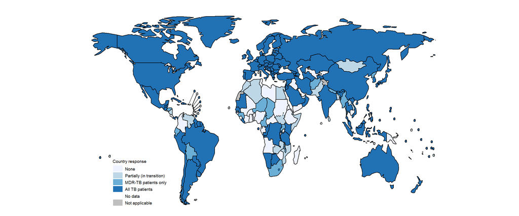